# Data 621 Homework 5: Wine

Tommy Jenkins, Violeta Stoyanova, Todd Weigel, Peter Kowalchuk, Eleanor R-Secoquian, Anthony Pagan

12/05/2019

## 0.1 OVERVIEW

In this homework assignment, we will explore, analyze and model a data set containing information on approximately 12,000 commercially available wines. The variables are mostly related to the chemical properties of the wine being sold. The response variable is the number of sample cases of wine that were purchased by wine distribution companies after sampling a wine. These cases would be used to provide tasting samples to restaurants and wine stores around the United States. The more sample cases purchased, the more likely is a wine to be sold at a high end restaurant. A large wine manufacturer is studying the data in order to predict the number of wine cases ordered based upon the wine characteristics. If the wine manufacturer can predict the number of cases, then that manufacturer will be able to adjust their wine offering to maximize sales.

## 0.2 Objective:

Our objective is to build a count regression model to predict the number of cases of wine that will be sold given certain properties of the wine. HINT: Sometimes, the fact that a variable is missing is actually predictive of the target. You can only use the variables given to you (or variables that you derive from the variables provided).

Below is a short description of the variables of interest in the data set:

| Variable Name | Definition | Theoretical Effect |
| --- | --- | --- |
| INDEX | Identification Variable (do not use) | None |
| TARGET | Number of Cases Purchased | None |
| AcidIndex | Proprietary method of testing total acidity of wine by using a weighted average |  |
| Alcohol | Alcohol Content |  |
| Chlorides | Chloride content of wine |  |
| CitricAcid | Citric Acid Content |  |
| Density | Density of Wine |  |
| FixedAcidity | Fixed Acidity of Wine |  |
| FreeSulfurDioxide | Sulfur Dioxide content of wine |  |
| LabelAppeal | Marketing Score indicating the appeal of label design for consumers. High numbers suggest customers like the label design. Negative numbers suggest customes don’t like the design. | Many consumers purchase based on the visual appeal of the wine label design. Higher numbers suggest better sales |
| ResidualSugar | Residual Sugar of wine |  |
| STARS | Wine rating by a team of experts. 4 Stars = Excellent, 1 Star = Poor | A high number of stars suggests high sales |
| Sulphates | Sulfate conten of wine |  |
| TotalSulfurDioxide | Total Sulfur Dioxide of Wine |  |
| VolatileAcidity | Volatile Acid content of wine |  |
| pH | pH of wine |  |

# 1 DATA EXPLORATION

## 1.1 Data Summary

With over 12,000 observations in our sample, we must look into the data and explore key summary statistics. We also calculate the counts for NA’s, 0, negative, and unique values.

```
##      INDEX           TARGET       FixedAcidity     VolatileAcidity
##  Min.   :    1   Min.   :0.000   Min.   :-18.100   Min.   :-2.7900
##  1st Qu.: 4038   1st Qu.:2.000   1st Qu.:  5.200   1st Qu.: 0.1300
##  Median : 8110   Median :3.000   Median :  6.900   Median : 0.2800
##  Mean   : 8070   Mean   :3.029   Mean   :  7.076   Mean   : 0.3241
##  3rd Qu.:12106   3rd Qu.:4.000   3rd Qu.:  9.500   3rd Qu.: 0.6400
##  Max.   :16129   Max.   :8.000   Max.   : 34.400   Max.   : 3.6800
##
##    CitricAcid      ResidualSugar        Chlorides       FreeSulfurDioxide
##  Min.   :-3.2400   Min.   :-127.800   Min.   :-1.1710   Min.   :-555.00
##  1st Qu.: 0.0300   1st Qu.:  -2.000   1st Qu.:-0.0310   1st Qu.:   0.00
##  Median : 0.3100   Median :   3.900   Median : 0.0460   Median :  30.00
##  Mean   : 0.3084   Mean   :   5.419   Mean   : 0.0548   Mean   :  30.85
##  3rd Qu.: 0.5800   3rd Qu.:  15.900   3rd Qu.: 0.1530   3rd Qu.:  70.00
##  Max.   : 3.8600   Max.   : 141.150   Max.   : 1.3510   Max.   : 623.00
##                    NA's   :616        NA's   :638       NA's   :647
##  TotalSulfurDioxide    Density             pH          Sulphates
##  Min.   :-823.0     Min.   :0.8881   Min.   :0.480   Min.   :-3.1300
##  1st Qu.:  27.0     1st Qu.:0.9877   1st Qu.:2.960   1st Qu.: 0.2800
##  Median : 123.0     Median :0.9945   Median :3.200   Median : 0.5000
##  Mean   : 120.7     Mean   :0.9942   Mean   :3.208   Mean   : 0.5271
##  3rd Qu.: 208.0     3rd Qu.:1.0005   3rd Qu.:3.470   3rd Qu.: 0.8600
##  Max.   :1057.0     Max.   :1.0992   Max.   :6.130   Max.   : 4.2400
##  NA's   :682                         NA's   :395     NA's   :1210
##     Alcohol       LabelAppeal          AcidIndex          STARS
##  Min.   :-4.70   Min.   :-2.000000   Min.   : 4.000   Min.   :1.000
##  1st Qu.: 9.00   1st Qu.:-1.000000   1st Qu.: 7.000   1st Qu.:1.000
##  Median :10.40   Median : 0.000000   Median : 8.000   Median :2.000
##  Mean   :10.49   Mean   :-0.009066   Mean   : 7.773   Mean   :2.042
##  3rd Qu.:12.40   3rd Qu.: 1.000000   3rd Qu.: 8.000   3rd Qu.:3.000
##  Max.   :26.50   Max.   : 2.000000   Max.   :17.000   Max.   :4.000
##  NA's   :653                                          NA's   :3359
```

|  | vars | n | mean | sd | median | trimmed | mad | min | max | range | skew | kurtosis | se | na_count | neg_count | zero_count | unique_count |
| --- | --- | --- | --- | --- | --- | --- | --- | --- | --- | --- | --- | --- | --- | --- | --- | --- | --- |
| TARGET | 1 | 12795 | 3.0290739 | 1.9263682 | 3.00000 | 3.0538244 | 1.4826000 | 0.00000 | 8.00000 | 8.00000 | -0.3263010 | -0.8772457 | 0.0170302 | 0 | 0 | 2734 | 9 |
| FixedAcidity | 2 | 12795 | 7.0757171 | 6.3176435 | 6.90000 | 7.0736739 | 3.2617200 | -18.10000 | 34.40000 | 52.50000 | -0.0225860 | 1.6749987 | 0.0558515 | 0 | 1621 | 548 | 470 |
| VolatileAcidity | 3 | 12795 | 0.3241039 | 0.7840142 | 0.28000 | 0.3243890 | 0.4299540 | -2.79000 | 3.68000 | 6.47000 | 0.0203800 | 1.8322106 | 0.0069311 | 0 | 2827 | 9982 | 815 |
| CitricAcid | 4 | 12795 | 0.3084127 | 0.8620798 | 0.31000 | 0.3102520 | 0.4151280 | -3.24000 | 3.86000 | 7.10000 | -0.0503070 | 1.8379401 | 0.0076213 | 0 | 2966 | 9686 | 602 |
| ResidualSugar | 5 | 12179 | 5.4187331 | 33.7493790 | 3.90000 | 5.5800410 | 15.7155600 | -127.80000 | 141.15000 | 268.95000 | -0.0531229 | 1.8846917 | 0.3058158 | 616 | NA | NA | 2078 |
| Chlorides | 6 | 12157 | 0.0548225 | 0.3184673 | 0.04600 | 0.0540159 | 0.1349166 | -1.17100 | 1.35100 | 2.52200 | 0.0304272 | 1.7886044 | 0.0028884 | 638 | NA | NA | 1664 |
| FreeSulfurDioxide | 7 | 12148 | 30.8455713 | 148.7145577 | 30.00000 | 30.9334877 | 56.3388000 | -555.00000 | 623.00000 | 1178.00000 | 0.0063930 | 1.8364966 | 1.3492769 | 647 | NA | NA | 1000 |
| TotalSulfurDioxide | 8 | 12113 | 120.7142326 | 231.9132105 | 123.00000 | 120.8895367 | 134.9166000 | -823.00000 | 1057.00000 | 1880.00000 | -0.0071794 | 1.6746665 | 2.1071703 | 682 | NA | NA | 1371 |
| Density | 9 | 12795 | 0.9942027 | 0.0265376 | 0.99449 | 0.9942130 | 0.0093552 | 0.88809 | 1.09924 | 0.21115 | -0.0186938 | 1.8999592 | 0.0002346 | 0 | 0 | 9492 | 5933 |
| pH | 10 | 12400 | 3.2076282 | 0.6796871 | 3.20000 | 3.2055706 | 0.3854760 | 0.48000 | 6.13000 | 5.65000 | 0.0442880 | 1.6462681 | 0.0061038 | 395 | NA | NA | 498 |
| Sulphates | 11 | 11585 | 0.5271118 | 0.9321293 | 0.50000 | 0.5271453 | 0.4447800 | -3.13000 | 4.24000 | 7.37000 | 0.0059119 | 1.7525655 | 0.0086602 | 1210 | NA | NA | 631 |
| Alcohol | 12 | 12142 | 10.4892363 | 3.7278190 | 10.40000 | 10.5018255 | 2.3721600 | -4.70000 | 26.50000 | 31.20000 | -0.0307158 | 1.5394949 | 0.0338306 | 653 | NA | NA | 402 |
| LabelAppeal | 13 | 12795 | -0.0090660 | 0.8910892 | 0.00000 | -0.0099639 | 1.4826000 | -2.00000 | 2.00000 | 4.00000 | 0.0084295 | -0.2622916 | 0.0078777 | 0 | 3640 | 5617 | 5 |
| AcidIndex | 14 | 12795 | 7.7727237 | 1.3239264 | 8.00000 | 7.6431572 | 1.4826000 | 4.00000 | 17.00000 | 13.00000 | 1.6484959 | 5.1900925 | 0.0117043 | 0 | 0 | 0 | 14 |
| STARS | 15 | 9436 | 2.0417550 | 0.9025400 | 2.00000 | 1.9711258 | 1.4826000 | 1.00000 | 4.00000 | 3.00000 | 0.4472353 | -0.6925343 | 0.0092912 | 3359 | NA | NA | 5 |

We visualize these counts per variable and then explore solutions further below.

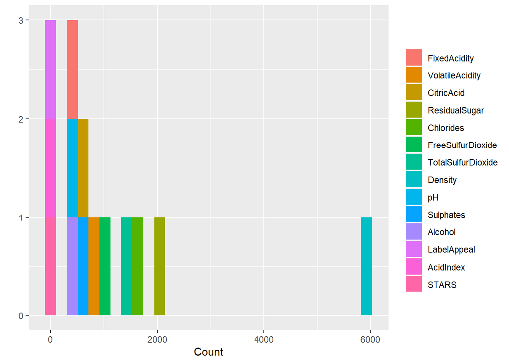

The dataset consists of two data files: training and evaluation. The training dataset contains 16 columns, and the evaluation dataset also contains 16 columns.

## 1.2 Missing Data

An important aspect of any dataset is to determine how much, if any, data is missing. We look at all the variables to see which if any have missing data. We look at the basic descriptive statistics as well as the missing data and percentages.

We start by looking at the dataset as a whole and determine how many complete rows, that is rows with data for all predictors we have.

```
##    Mode   FALSE    TRUE
## logical    6359    6436
```

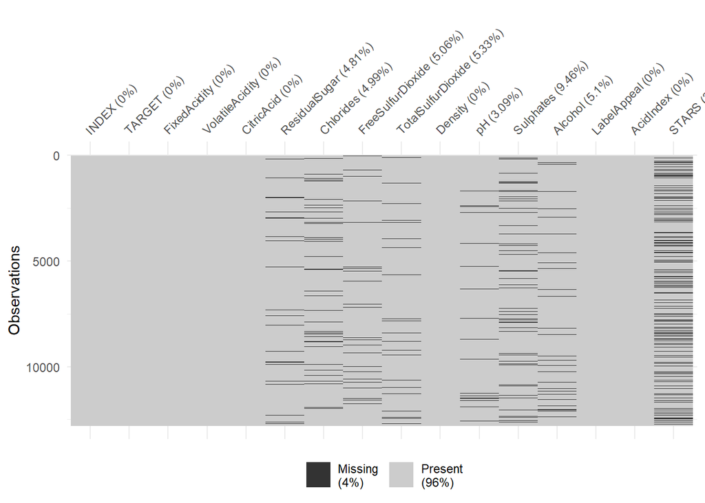

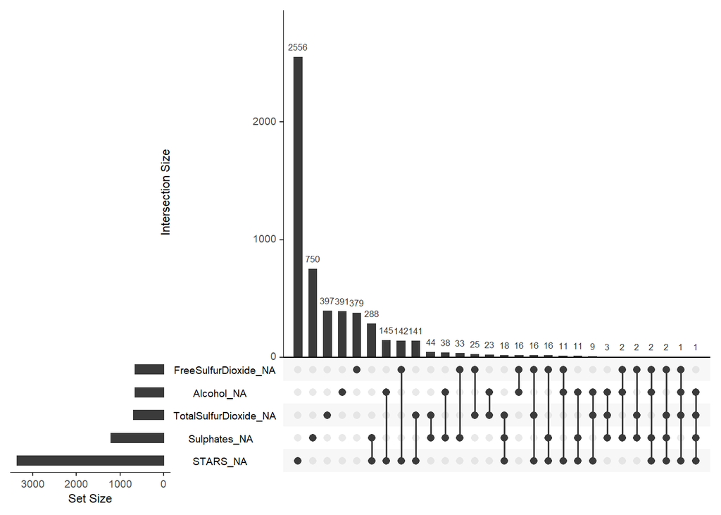

With these results, if we remove all rows with incomplete rows, there will be a total of 6436 rows out of 12795 .If we eliminate all non-complete rows and keep only rows with data for all the predictors in the dataset, our new dataset will results in 50% of the total dataset. We create a subset of data with complete cases if needed later in our analysis.

```
## Observations: 6,436
## Variables: 16
## $ INDEX              <int> 4, 5, 13, 14, 16, 23, 24, 25, 26, 27, 28, 32, 34...
## $ TARGET             <int> 5, 3, 6, 0, 3, 4, 5, 4, 3, 2, 3, 4, 4, 3, 4, 3, ...
## $ FixedAcidity       <dbl> 7.1, 5.7, 5.5, -17.2, 6.0, -1.3, 10.0, 6.8, 5.8,...
## $ VolatileAcidity    <dbl> 2.640, 0.385, -0.220, 0.520, 0.330, 0.220, 0.230...
## $ CitricAcid         <dbl> -0.88, 0.04, 0.39, 0.15, -1.06, 2.95, 0.27, -0.2...
## $ ResidualSugar      <dbl> 14.80, 18.80, 1.80, -33.80, 3.00, -53.00, 14.10,...
## $ Chlorides          <dbl> 0.037, -0.425, -0.277, -0.022, 0.518, 0.541, 0.0...
## $ FreeSulfurDioxide  <dbl> 214, 22, 62, 551, 5, -85, -188, -88, 87, 15, 32,...
## $ TotalSulfurDioxide <dbl> 142, 115, 180, 65, 378, -266, 229, 508, -283, 60...
## $ Density            <dbl> 0.99518, 0.99640, 0.94724, 0.99340, 0.96643, 0.9...
## $ pH                 <dbl> 3.12, 2.24, 3.09, 4.31, 3.55, 3.61, 3.14, 3.23, ...
## $ Sulphates          <dbl> 0.48, 1.83, 0.75, 0.56, -0.86, 0.82, 0.88, 0.35,...
## $ Alcohol            <dbl> 22.0, 6.2, 12.6, 13.1, 3.9, 10.0, 11.0, 18.3, 11...
## $ LabelAppeal        <int> -1, -1, 0, 1, 1, 0, 1, -1, -1, -1, 0, 0, 1, -1, ...
## $ AcidIndex          <int> 8, 6, 8, 5, 7, 8, 11, 8, 6, 7, 8, 7, 7, 8, 6, 9,...
## $ STARS              <int> 3, 1, 4, 1, 2, 3, 2, 2, 1, 1, 1, 2, 2, 1, 3, 1, ...
```

## 1.3 Visualization

We consider each variable

### 1.3.1 Target Variable

The distribution of our target variable is normal with the exception of many 0 Wine count entries. At such a high percentage, the zero scores likely reflect lack of popularity rather than error, especially if they get low human ratings.

#### 1.3.1.1 Histogram

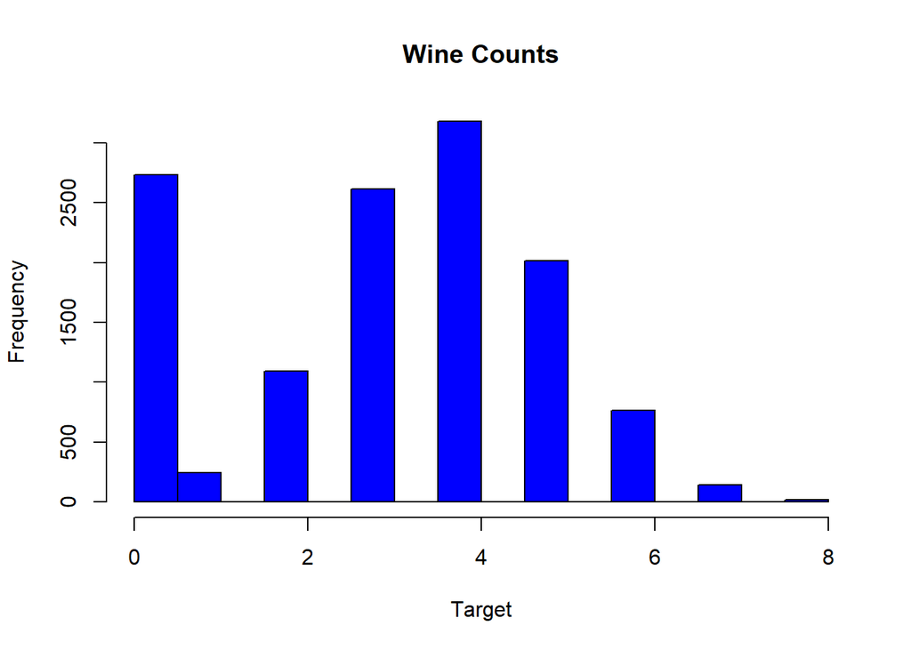

#### 1.3.1.2 Integers

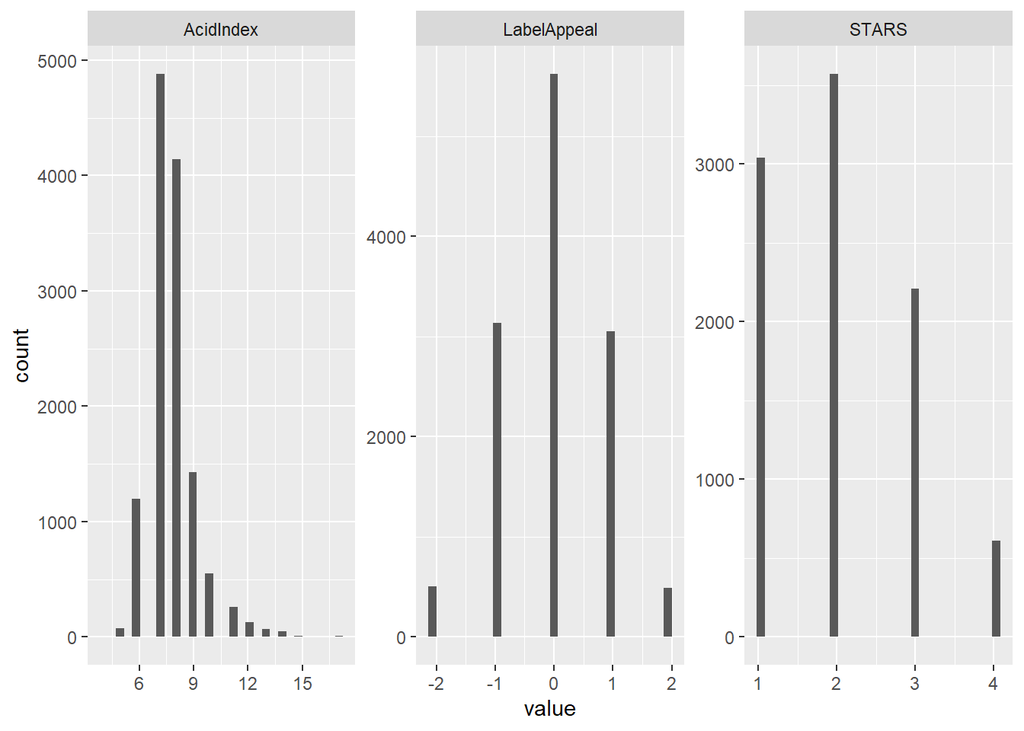

#### 1.3.1.3 Doubles

The Double variable types look very similar to one another, and look somewhat normal. These look okay to impute after we’ve run our diagnostic plots.

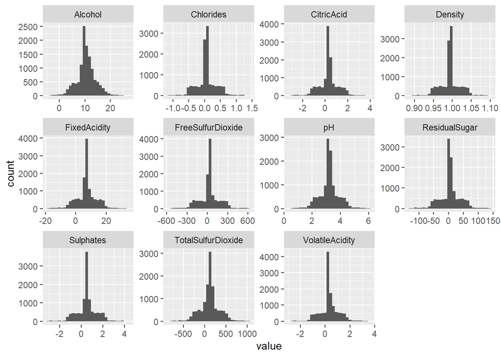

### 1.3.2 Outliers

#### 1.3.2.1 Boxplot

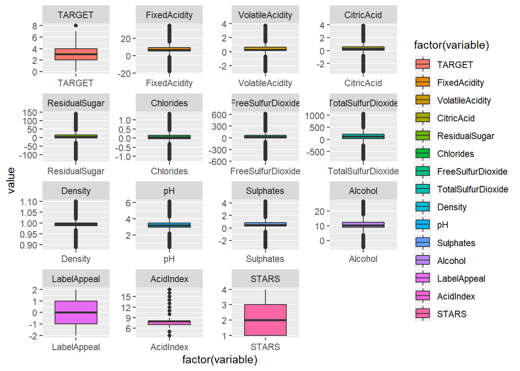

#### Boxplot Without outliers

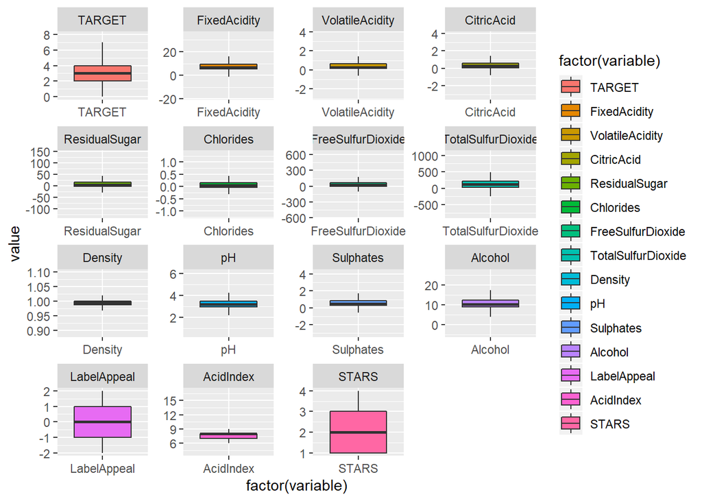

#### 1.3.2.2 Correlation

We note that the human ratings all have high correlations than do our chemical features.

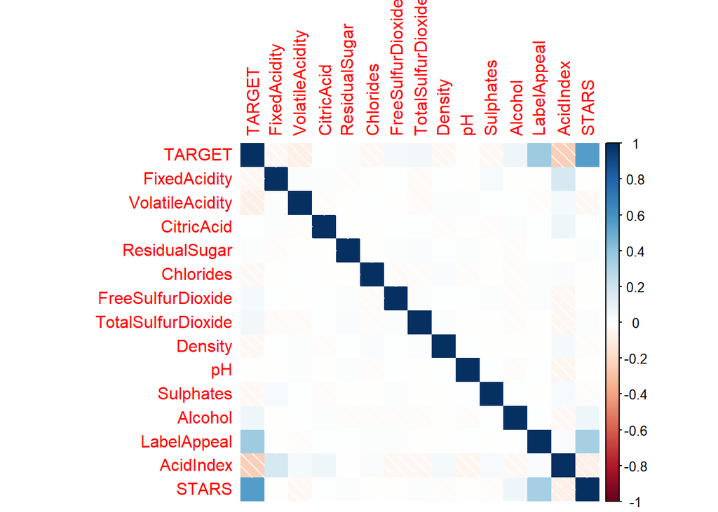

# 2 DATA PREPARATION

```
##                    na_count neg_count zero_count unique_count
## TARGET                    0         0       2734            9
## FixedAcidity              0      1621        548          470
## VolatileAcidity           0      2827       9982          815
## CitricAcid                0      2966       9686          602
## ResidualSugar           616        NA         NA         2078
## Chlorides               638        NA         NA         1664
## FreeSulfurDioxide       647        NA         NA         1000
## TotalSulfurDioxide      682        NA         NA         1371
## Density                   0         0       9492         5933
## pH                      395        NA         NA          498
## Sulphates              1210        NA         NA          631
## Alcohol                 653        NA         NA          402
## LabelAppeal               0      3640       5617            5
## AcidIndex                 0         0          0           14
## STARS                  3359        NA         NA            5
```

```
##                    na_count neg_count zero_count unique_count
## STARS                  3359        NA         NA            5
## Sulphates              1210        NA         NA          631
## TotalSulfurDioxide      682        NA         NA         1371
## Alcohol                 653        NA         NA          402
## FreeSulfurDioxide       647        NA         NA         1000
## Chlorides               638        NA         NA         1664
## ResidualSugar           616        NA         NA         2078
## pH                      395        NA         NA          498
## TARGET                    0         0       2734            9
## FixedAcidity              0      1621        548          470
## VolatileAcidity           0      2827       9982          815
## CitricAcid                0      2966       9686          602
## Density                   0         0       9492         5933
## LabelAppeal               0      3640       5617            5
## AcidIndex                 0         0          0           14
```

```
##                    na_count neg_count zero_count unique_count
## LabelAppeal               0      3640       5617            5
## CitricAcid                0      2966       9686          602
## VolatileAcidity           0      2827       9982          815
## FixedAcidity              0      1621        548          470
## TARGET                    0         0       2734            9
## Density                   0         0       9492         5933
## AcidIndex                 0         0          0           14
## ResidualSugar           616        NA         NA         2078
## Chlorides               638        NA         NA         1664
## FreeSulfurDioxide       647        NA         NA         1000
## TotalSulfurDioxide      682        NA         NA         1371
## pH                      395        NA         NA          498
## Sulphates              1210        NA         NA          631
## Alcohol                 653        NA         NA          402
## STARS                  3359        NA         NA            5
```

By the same logic we will leave the zero counts alone until normalization. We can exclude the TARGET variable unless we will be normalizing it specifically for our later work.

```
##                    na_count neg_count zero_count unique_count
## VolatileAcidity           0      2827       9982          815
## CitricAcid                0      2966       9686          602
## Density                   0         0       9492         5933
## LabelAppeal               0      3640       5617            5
## TARGET                    0         0       2734            9
## FixedAcidity              0      1621        548          470
## AcidIndex                 0         0          0           14
## ResidualSugar           616        NA         NA         2078
## Chlorides               638        NA         NA         1664
## FreeSulfurDioxide       647        NA         NA         1000
## TotalSulfurDioxide      682        NA         NA         1371
## pH                      395        NA         NA          498
## Sulphates              1210        NA         NA          631
## Alcohol                 653        NA         NA          402
## STARS                  3359        NA         NA            5
```

We want to take a look at the least unique counts next, and by a large margin LabelAppeal, STARS, and AcidIndex show low unique counts. We can exclude TARGET until we analyze our feature transformation decisions. We see that AcidIndex is a proprietary weighted method for measuring Acid. We do not need to impute this, given its complexity and relative influence, and the risk or changing our results our very small ranges.

```
##                    na_count neg_count zero_count unique_count
## LabelAppeal               0      3640       5617            5
## STARS                  3359        NA         NA            5
## TARGET                    0         0       2734            9
## AcidIndex                 0         0          0           14
## Alcohol                 653        NA         NA          402
## FixedAcidity              0      1621        548          470
## pH                      395        NA         NA          498
## CitricAcid                0      2966       9686          602
## Sulphates              1210        NA         NA          631
## VolatileAcidity           0      2827       9982          815
## FreeSulfurDioxide       647        NA         NA         1000
## TotalSulfurDioxide      682        NA         NA         1371
## Chlorides               638        NA         NA         1664
## ResidualSugar           616        NA         NA         2078
## Density                   0         0       9492         5933
```

# 3 BUILD MODEL

## 3.1 Model 1: Poisson Regression (all predictors)

For the first model, we used the Poisson regression and all of the predictors.

```
##
## Call:
## glm(formula = TARGET ~ . - INDEX, family = poisson, data = WineTrain)
##
## Deviance Residuals:
##     Min       1Q   Median       3Q      Max
## -3.3301  -0.2799   0.0536   0.3861   1.7744
##
## Coefficients:
##                      Estimate Std. Error z value Pr(>|z|)
## (Intercept)         1.688e+00  2.503e-01   6.742 1.56e-11 ***
## FixedAcidity        4.868e-04  1.053e-03   0.462   0.6438
## VolatileAcidity    -2.481e-02  8.362e-03  -2.968   0.0030 **
## CitricAcid         -1.614e-03  7.578e-03  -0.213   0.8313
## ResidualSugar      -6.875e-05  1.939e-04  -0.355   0.7229
## Chlorides          -3.327e-02  2.053e-02  -1.621   0.1050
## FreeSulfurDioxide   6.032e-05  4.399e-05   1.371   0.1703
## TotalSulfurDioxide  2.141e-05  2.854e-05   0.750   0.4531
## Density            -3.695e-01  2.462e-01  -1.501   0.1334
## pH                 -2.547e-03  9.608e-03  -0.265   0.7909
## Sulphates          -6.672e-03  7.051e-03  -0.946   0.3440
## Alcohol             4.443e-03  1.772e-03   2.507   0.0122 *
## LabelAppeal         1.783e-01  7.958e-03  22.403  < 2e-16 ***
## AcidIndex          -4.762e-02  5.911e-03  -8.056 7.88e-16 ***
## STARS2              3.232e-01  1.740e-02  18.574  < 2e-16 ***
## STARS3              4.387e-01  1.896e-02  23.134  < 2e-16 ***
## STARS4              5.509e-01  2.688e-02  20.491  < 2e-16 ***
## ---
## Signif. codes:  0 '***' 0.001 '**' 0.01 '*' 0.05 '.' 0.1 ' ' 1
##
## (Dispersion parameter for poisson family taken to be 1)
##
##     Null deviance: 5844.1  on 6435  degrees of freedom
## Residual deviance: 3928.8  on 6419  degrees of freedom
##   (6359 observations deleted due to missingness)
## AIC: 23095
##
## Number of Fisher Scoring iterations: 5
```

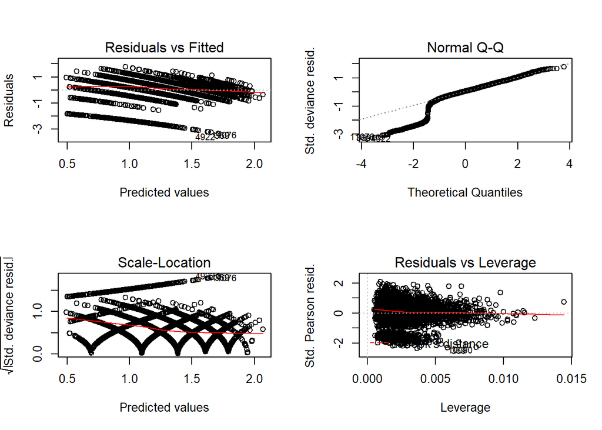

## 3.2 Model 2: Poisson Regression (reduced predictors)

For the second model, based on model 1, we reduced the number of predictors.

```
##
## Call:
## glm(formula = TARGET ~ VolatileAcidity + CitricAcid + Chlorides +
##     FreeSulfurDioxide + TotalSulfurDioxide + Density + pH + Sulphates +
##     Alcohol + LabelAppeal + AcidIndex + STARS, family = poisson,
##     data = WineTrain)
##
## Deviance Residuals:
##     Min       1Q   Median       3Q      Max
## -3.3170  -0.2829   0.0543   0.3858   1.7731
##
## Coefficients:
##                      Estimate Std. Error z value Pr(>|z|)
## (Intercept)         1.669e+00  2.442e-01   6.832 8.37e-12 ***
## VolatileAcidity    -2.319e-02  8.142e-03  -2.849  0.00439 **
## CitricAcid         -4.347e-04  7.395e-03  -0.059  0.95313
## Chlorides          -2.918e-02  2.000e-02  -1.459  0.14447
## FreeSulfurDioxide   7.263e-05  4.282e-05   1.696  0.08987 .
## TotalSulfurDioxide  2.206e-05  2.785e-05   0.792  0.42828
## Density            -3.417e-01  2.402e-01  -1.422  0.15491
## pH                 -3.949e-03  9.411e-03  -0.420  0.67478
## Sulphates          -6.911e-03  6.869e-03  -1.006  0.31437
## Alcohol             4.113e-03  1.730e-03   2.377  0.01743 *
## LabelAppeal         1.766e-01  7.744e-03  22.801  < 2e-16 ***
## AcidIndex          -4.784e-02  5.720e-03  -8.363  < 2e-16 ***
## STARS2              3.283e-01  1.700e-02  19.307  < 2e-16 ***
## STARS3              4.443e-01  1.852e-02  23.996  < 2e-16 ***
## STARS4              5.556e-01  2.611e-02  21.280  < 2e-16 ***
## ---
## Signif. codes:  0 '***' 0.001 '**' 0.01 '*' 0.05 '.' 0.1 ' ' 1
##
## (Dispersion parameter for poisson family taken to be 1)
##
##     Null deviance: 6145.7  on 6746  degrees of freedom
## Residual deviance: 4123.6  on 6732  degrees of freedom
##   (6048 observations deleted due to missingness)
## AIC: 24216
##
## Number of Fisher Scoring iterations: 5
```

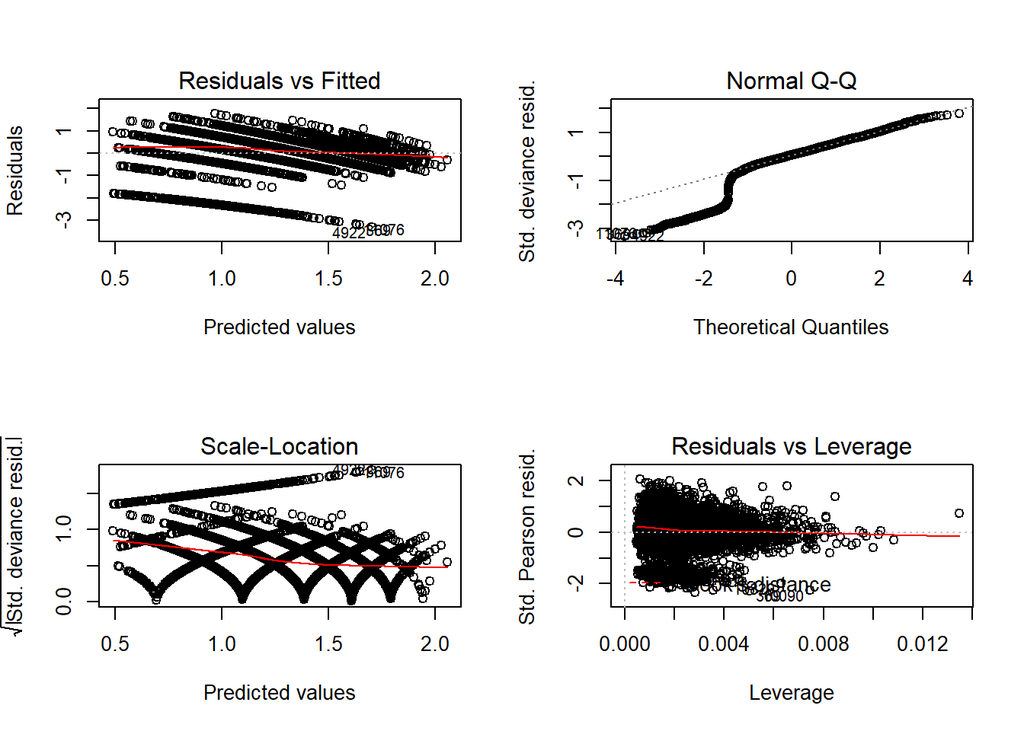

```
##
## Call:
## glm(formula = TARGET ~ VolatileAcidity + FreeSulfurDioxide +
##     TotalSulfurDioxide + Chlorides + Density + pH + Sulphates +
##     LabelAppeal + AcidIndex + STARS, family = gaussian, data = WineTrain)
##
## Deviance Residuals:
##     Min       1Q   Median       3Q      Max
## -5.1949  -0.5359   0.0996   0.7405   3.3160
##
## Coefficients:
##                      Estimate Std. Error t value Pr(>|t|)
## (Intercept)         5.331e+00  5.229e-01  10.194  < 2e-16 ***
## VolatileAcidity    -8.491e-02  1.740e-02  -4.881 1.08e-06 ***
## FreeSulfurDioxide   2.752e-04  9.243e-05   2.978  0.00291 **
## TotalSulfurDioxide  7.090e-05  5.952e-05   1.191  0.23358
## Chlorides          -1.158e-01  4.293e-02  -2.697  0.00701 **
## Density            -1.300e+00  5.169e-01  -2.516  0.01191 *
## pH                 -1.875e-03  2.020e-02  -0.093  0.92607
## Sulphates          -2.413e-02  1.471e-02  -1.641  0.10092
## LabelAppeal         6.411e-01  1.649e-02  38.878  < 2e-16 ***
## AcidIndex          -1.611e-01  1.153e-02 -13.966  < 2e-16 ***
## STARS2              1.005e+00  3.313e-02  30.326  < 2e-16 ***
## STARS3              1.513e+00  3.839e-02  39.411  < 2e-16 ***
## STARS4              2.151e+00  6.199e-02  34.701  < 2e-16 ***
## ---
## Signif. codes:  0 '***' 0.001 '**' 0.01 '*' 0.05 '.' 0.1 ' ' 1
##
## (Dispersion parameter for gaussian family taken to be 1.319364)
##
##     Null deviance: 17036.4  on 7102  degrees of freedom
## Residual deviance:  9354.3  on 7090  degrees of freedom
##   (5692 observations deleted due to missingness)
## AIC: 22141
##
## Number of Fisher Scoring iterations: 2
```

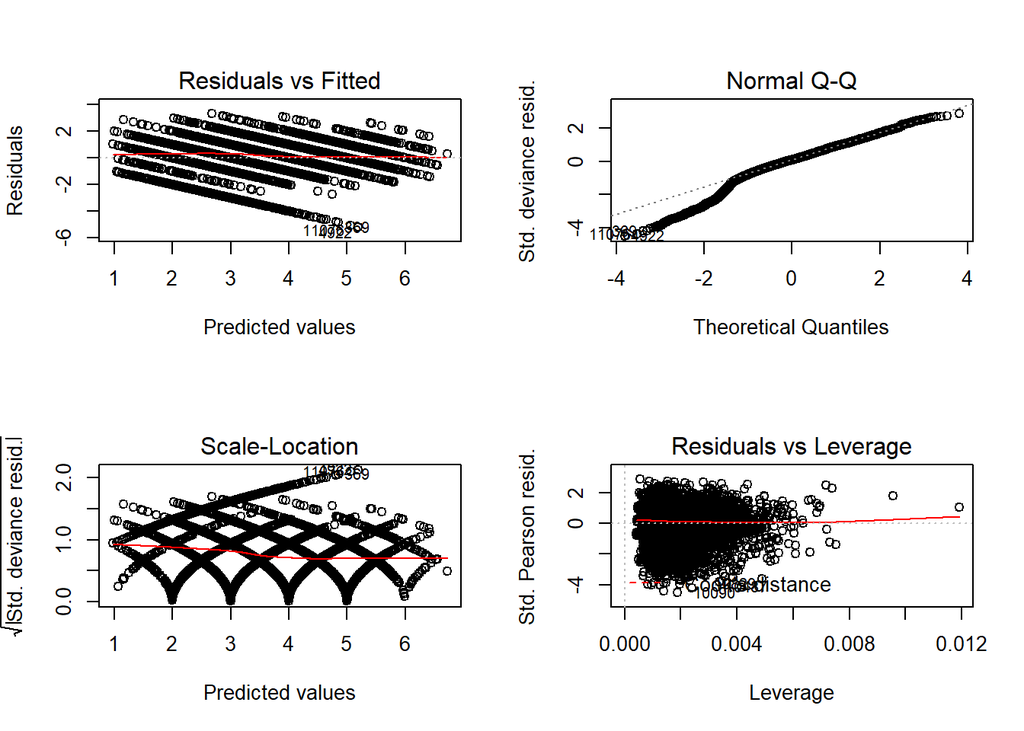

Model 3 shows a better Q-Q plot than the previous two models.

## 3.4 Model 4: Negative Binomial Regression

```
##
## Call:
## glm(formula = TARGET ~ VolatileAcidity + TotalSulfurDioxide +
##     pH + Sulphates + LabelAppeal + AcidIndex + STARS, family = negative.binomial(1),
##     data = WineTrain)
##
## Deviance Residuals:
##      Min        1Q    Median        3Q       Max
## -1.93848  -0.13164   0.02425   0.17731   0.87362
##
## Coefficients:
##                      Estimate Std. Error t value Pr(>|t|)
## (Intercept)         1.443e+00  3.642e-02  39.613  < 2e-16 ***
## VolatileAcidity    -2.766e-02  5.397e-03  -5.125 3.04e-07 ***
## TotalSulfurDioxide  2.430e-05  1.823e-05   1.333   0.1827
## pH                 -3.613e-03  6.190e-03  -0.584   0.5595
## Sulphates          -8.920e-03  4.527e-03  -1.970   0.0488 *
## LabelAppeal         1.862e-01  5.081e-03  36.649  < 2e-16 ***
## AcidIndex          -5.607e-02  3.622e-03 -15.480  < 2e-16 ***
## STARS2              3.232e-01  1.037e-02  31.160  < 2e-16 ***
## STARS3              4.375e-01  1.185e-02  36.914  < 2e-16 ***
## STARS4              5.464e-01  1.839e-02  29.716  < 2e-16 ***
## ---
## Signif. codes:  0 '***' 0.001 '**' 0.01 '*' 0.05 '.' 0.1 ' ' 1
##
## (Dispersion parameter for Negative Binomial(1) family taken to be 0.1073286)
##
##     Null deviance: 2393.6  on 7878  degrees of freedom
## Residual deviance: 1870.2  on 7869  degrees of freedom
##   (4916 observations deleted due to missingness)
## AIC: 37774
##
## Number of Fisher Scoring iterations: 5
```

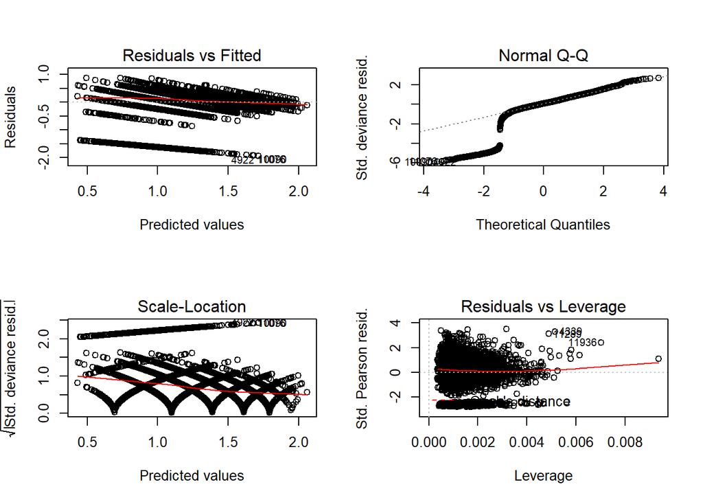

# 4 SELECT MODEL

## 4.1 Pick the best regression model

|  | Model 1 | Model 2 | Model 3 | Model 4 |
| --- | --- | --- | --- | --- |
| AIC | 23095.3698167386 | 24216.2765273715 | 22141.0249335269 | 37774.0980469856 |
| BIC | 23210.4540793765 | 24318.5293259809 | 22237.1807486529 | 37843.8176096981 |

With 4 models computed, we select the model with the lowest combination of AIC and BIC. From the table, we can see the model to pick is model 3

#CONCLUSION

Model 3 showed the best result. We can observe its performance by plotting the datasets TARGET values agaisnt the predicted values. One thing we observe is that the model doesn’t predict a TARGET of 8.

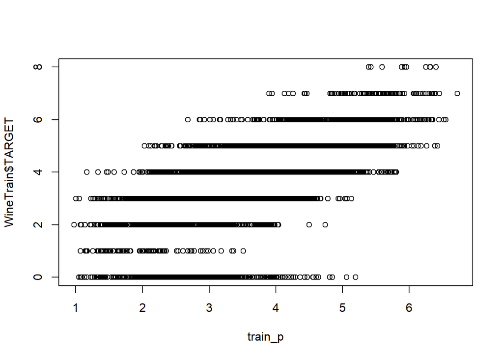

Other models, although of worse performace according to our selection metric, do show results of TARGET 8, but as can be seen in the graph below, they do not corresponde to real TARGET 8 classifications.

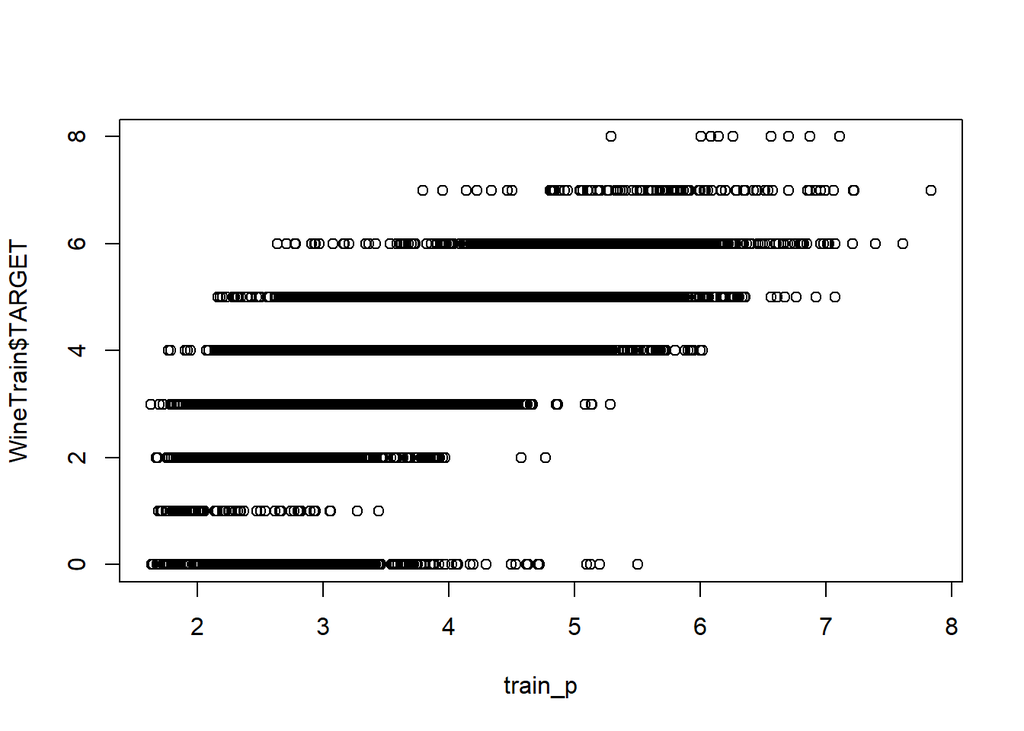

# 5 APPENDIX

**Code used in analysis**

```r
knitr::opts_chunk$set(echo = FALSE, warning = FALSE)
require(knitr)
library(MASS)
library(psych)
library(kableExtra)
library(tidyverse)
library(faraway)
library(gridExtra)
library(reshape2)
library(leaps)
library(caret)
library(naniar)
library(pander)
library(pROC)
library(corrplot)
#library(jtools)
WineTrain <- read.csv("https://raw.githubusercontent.com/pkowalchuk/CUNY621-HW5/master/wine-training-data.csv",fileEncoding="UTF-8-BOM",na.strings="",header=TRUE)
WineTrain1 <- WineTrain
WineEval <- read.csv("https://raw.githubusercontent.com/pkowalchuk/CUNY621-HW5/master/wine-evaluation-data.csv",fileEncoding="UTF-8-BOM",na.strings="",header=TRUE)
vr <- c("INDEX", "TARGET", "AcidIndex", "Alcohol", "Chlorides", "CitricAcid", "Density", "FixedAcidity", "FreeSulfurDioxide", "LabelAppeal", "ResidualSugar", "STARS", "Sulphates", "TotalSulfurDioxide", "VolatileAcidity", "pH")
def <- c("Identification Variable (do not use)", "Number of Cases Purchased", "Proprietary method of testing total acidity of wine by using a weighted average", "Alcohol Content", "Chloride content of wine", "Citric Acid Content", "Density of Wine", "Fixed Acidity of Wine", "Sulfur Dioxide content of wine", "Marketing Score indicating the appeal of label design for consumers. High numbers suggest customers like the label design. Negative numbers suggest customes don't like the design.", "Residual Sugar of wine", "Wine rating by a team of experts. 4 Stars = Excellent, 1 Star = Poor", "Sulfate conten of wine", "Total Sulfur Dioxide of Wine", "Volatile Acid content of wine", "pH of wine")
te <- c("None", "None", "", "",  "", "", "", "",  "", "Many consumers purchase based on the visual appeal of the wine label design. Higher numbers suggest better sales", "", "A high number of stars suggests high sales",  "", "", "", "")
kable(cbind(vr, def, te), col.names = c("Variable Name", "Definition", "Theoretical Effect")) %>%
  kable_styling()
#glimpse(WineTrain)
#colnames(WineTrain[-1])<-"INDEX"
summary(WineTrain)

var_stats<- function(WineTrain){
  wt <- WineTrain[-1]
  wine1 <- describe(wt)
  #wine1$na_count <- sapply(WineTrain[-1], function(y) sum(length(which(is.na(y)))))
  wine1$na_count <- sapply(wt, function(y) sum(is.na(y)))
  wine1$neg_count <- sapply(wt, function(y) sum(y<0))
  wine1$zero_count <- sapply(wt, function(y) sum(as.integer(y)==0))
  wine1$unique_count <- sapply(wt, function(y) sum(n_distinct(y)))

  return(wine1)
}
wine1 <- var_stats(WineTrain)

kable(wine1, "html", escape = F) %>%
  kable_styling("striped", full_width = T) %>%
  column_spec(1, bold = T) %>%
  scroll_box(width = "100%", height = "700px")

#  geom_point(data = wine1, color = "red", shape = 15, size = 5)

qplot(wine1[c(-1),]$unique_count,
      geom="auto",  xlab = "Count",
      fill=as_factor(rownames(wine1[c(-1),])))+
      theme(legend.title=element_blank())

colsTrain<-ncol(WineTrain)
colsEval<-ncol(WineEval)
missingCol<-colnames(WineTrain)[!(colnames(WineTrain) %in% colnames(WineEval))]
cc<-summary(complete.cases(WineTrain))
cWineTrain<-subset(WineTrain, complete.cases(WineTrain))
cc
vis_miss(WineTrain)
gg_miss_upset(WineTrain)
glimpse(cWineTrain)
WineTrain1$INDEX <- NULL
hist(WineTrain1$TARGET, col = "blue", xlab = " Target ", main = "Wine Counts")
WineTrain1[-1] %>%
  keep(is.integer) %>%
  gather() %>%
  ggplot(aes(value), main="") +
  facet_wrap(~ key, scales = "free") +
  geom_histogram()
WineTrain1 %>%
  keep(is.double) %>%
  gather() %>%
  ggplot(aes(value)) +
  facet_wrap(~ key, scales = "free") +
  geom_histogram()
ggplot(melt(WineTrain[-1]), aes(x=factor(variable), y=value, fill=factor(variable))) + facet_wrap(~variable, scale="free") + geom_boxplot()
ggplot(melt(WineTrain[-1]), aes(x=factor(variable), y=value, fill=factor(variable))) + facet_wrap(~variable, scale="free") + geom_boxplot(outlier.shape=NA)
corrplot(as.matrix(cor(WineTrain[-1], use = "pairwise.complete")),method = "shade")
print(wine1[,14:17])
print(wine1[order(-wine1$na_count),14:17])
#WineTrain$STARS <- sapply(WineTrain$STARS,function(x) ifelse(is.na(x),0,x))
#WineTrain<-as.factor(WineTrain)
#wine1 <- var_stats(WineTrain)
#mice imputation
#print(wine1[order(-wine1$na_count),14:17])
print(wine1[order(-wine1$neg_count),14:17])



print(wine1[order(-wine1$zero_count),14:17])
print(wine1[order(wine1$unique_count),14:17])

WineTrain$STARS<-as.factor(WineTrain$STARS)
WineEval$STARS<-as.factor(WineEval$STARS)
#WineTest
m1 <- glm(TARGET ~ .-INDEX , family = poisson, data = WineTrain)
#m1 <- glm(TARGET ~ ., family = poisson, data = WineTrain)
summary(m1)
par(mfrow = c(2,2))
plot(m1)
m2 <- glm(TARGET ~ VolatileAcidity + CitricAcid + Chlorides + FreeSulfurDioxide
                        + TotalSulfurDioxide + Density + pH + Sulphates + Alcohol + LabelAppeal
             + AcidIndex + STARS, family = poisson, data = WineTrain)
summary(m2)
par(mfrow = c(2,2))
plot(m2)
m3 <- glm(TARGET ~ VolatileAcidity + FreeSulfurDioxide + TotalSulfurDioxide + Chlorides + Density + pH + Sulphates + LabelAppeal + AcidIndex + STARS, family=gaussian, data = WineTrain)
summary(m3)
par(mfrow = c(2,2))
plot(m3)
m4 <- glm(TARGET ~ VolatileAcidity + TotalSulfurDioxide +
     pH + Sulphates + LabelAppeal + AcidIndex + STARS, family = negative.binomial(1),
     data = WineTrain)
summary(m4)
par(mfrow = c(2,2))
plot(m4)
m1AIC <- AIC(m1)
m1BIC <- BIC(m1)
m2AIC <- AIC(m2)
m2BIC <- BIC(m2)
m3AIC <- AIC(m3)
m3BIC <- BIC(m3)
m4AIC <- AIC(m4)
m4BIC <- BIC(m4)

AIC <- list(m1AIC, m2AIC, m3AIC, m4AIC)
BIC <- list(m1BIC, m2BIC, m3BIC, m4BIC)
kable(rbind(AIC, BIC), col.names = c("Model 1", "Model 2", "Model 3", "Model 4"))  %>%
  kable_styling(full_width = T)

eval_p<-predict(m3,WineEval, type = "response")
write.csv(eval_p,"predicted_eval_values.csv")
train_p<-predict(m3,WineTrain, type = "response")
plot(train_p,WineTrain$TARGET)
train_p<-predict(m2,WineTrain, type = "response")
plot(train_p,WineTrain$TARGET)
```